# Memory Allocation, Generators and streams

```python
import sys
import numpy as np
import matplotlib.pyplot as plt
%matplotlib inline

from time import time
import ipython_memory_usage as imu  # the ipython_memory_usage.py is a utility that measures the amount of memory used
imu.start_watching_memory()
```

```
In [4] used 0.0000 MiB RAM in 0.10s, peaked 0.00 MiB above current, total RAM usage 53.73 MiB
```

**Note:** about 53 MB are used from the get go.

### Define dot product function in Python

We will compare this function to using np.dot

```python
def python_dot(a,b):
    sum=0
    for i in range(len(a)):
        sum+=a[i]*b[i]
    return sum
```

```
In [5] used 0.0586 MiB RAM in 0.11s, peaked 0.00 MiB above current, total RAM usage 53.79 MiB
```

### Experiement 1: Comparing allocation time, python calc and numpy calc.

In the following code we measure the running time and memory required to compute the dot product. $\vec{a} \cdot \vec{a} = \sum_{i=1}^m a_i^2$

```python
%%time
for e in range(2,9):
    L=10**e
    start=time()
    #a=np.random.uniform(low=-1,high=1,size=(L,2))
    a=np.ones([L,2])
    t1=time()
    np.dot(a[:,0],a[:,1]),
    t2=time()
    if e<8:
        python_dot(a[:,0],a[:,1]),
        t3=time()
    else:
        t3=t2
    print 'e=',e,'size=',L*16*1e-6,'MB\t allocation=',(t1-start)/L,'numpy=',(t2-t1)/L,'python=',(t3-t2)/L
    sys.stdout.flush()
```

```
e= 2 size= 0.0016 MB	 allocation= 2.19345092773e-07 numpy= 2.69412994385e-07 python= 1.12056732178e-06
e= 3 size= 0.016 MB	 allocation= 3.00407409668e-08 numpy= 2.28881835938e-08 python= 1.51109695435e-06
e= 4 size= 0.16 MB	 allocation= 5.19752502441e-09 numpy= 3.19480895996e-09 python= 1.32250785828e-06
e= 5 size= 1.6 MB	 allocation= 8.88824462891e-09 numpy= 1.85012817383e-09 python= 1.04857206345e-06
e= 6 size= 16.0 MB	 allocation= 7.38716125488e-09 numpy= 1.25098228455e-09 python= 1.02542090416e-06
e= 7 size= 160.0 MB	 allocation= 6.64539337158e-09 numpy= 1.07510089874e-09 python= 9.9054980278e-07
e= 8 size= 1600.0 MB	 allocation= 6.62707805634e-09 numpy= 1.05766057968e-09 python= 0.0
CPU times: user 11 s, sys: 2.15 s, total: 13.1 s
Wall time: 11.9 s
In [6] used 1862.0117 MiB RAM in 12.02s, peaked 84.73 MiB above current, total RAM usage 1915.80 MiB
```

```python
%%time

a=np.random.uniform(low=-1,high=1,size=(L,2))
t1=time()
a.tofile('a.bin')
t2=time()
print 'write time per element:',(t2-t1)/L
!ls -lh *.bin
```

```
write time per element: 4.81800699234e-08
-rw-r--r--  1 yoavfreund  staff   1.5G Apr  2 12:08 a.bin
CPU times: user 2.78 s, sys: 3 s, total: 5.77 s
Wall time: 8.24 s
In [7] used 0.0430 MiB RAM in 8.35s, peaked 0.00 MiB above current, total RAM usage 1915.84 MiB
```

```python
# Free memory
a=[]
```

```
In [8] used -1525.8555 MiB RAM in 0.24s, peaked 1525.88 MiB above current, total RAM usage 389.99 MiB
```

### Using generators instead of arrays.

- **python lists** and **numpy arrays** store a whole sequence in memory.
- **generators** create the elements of a sequence one at a time.

```python
# A simple generator which generates the sequence 0,1,2,...,n-1
def range_generator(n):
    i=0
    while i<n:
        yield i
        i+=1
# the following commands all generate the same sequence, some using iteration, some using lists.
print type(range(4)),range(4),[i for i in range(4)]
print type(range_generator(4)),range_generator(4), [i for i in range_generator(4)]
print type(xrange(4)),xrange(4), [i for i in xrange(4)] # built-in generator that is equivalent to range_generator
```

```
<type 'list'> [0, 1, 2, 3] [0, 1, 2, 3]
<type 'generator'> <generator object range_generator at 0x10879ae60> [0, 1, 2, 3]
<type 'xrange'> xrange(4) [0, 1, 2, 3]
In [9] used -356.7891 MiB RAM in 0.11s, peaked 0.00 MiB above current, total RAM usage 33.20 MiB
```

`list`, `generator` and `xrange` are all "iterable", i.e. they can be used as X in "for a in X"

### Experiement 2: comparing the memory and time profile for different iterators.

compare different ways to generate vectors and to compute the dot product.

```python
L=int(1e7)
t0=time()
a=range(L)
print len(a)*8e-6,'MB'
t1=time()
python_dot(a,a)
t2=time()
print 'allocation time per byte',(t1-t0)/L,'computation time per byte is ',(t2-t1)/L
```

```
80.0 MB
allocation time per byte 3.20942878723e-08 computation time per byte is  1.59870100021e-07
In [10] used 617.9922 MiB RAM in 2.03s, peaked 0.00 MiB above current, total RAM usage 651.19 MiB
```

```python
a=[]  # release memory
```

```
In [11] used 0.0078 MiB RAM in 0.17s, peaked 0.00 MiB above current, total RAM usage 651.20 MiB
```

### Using iterators to perform the dot product

We now redefine python_dot so that it can take as input any two iterables and compute the dot product one element at a time.

Note that `iterator_dot` takes as input two iterators.

```python
import collections
def iterator_dot(a,b):
    s=0
    try:
        while True:
            s+=a.next()*b.next()
    except StopIteration:
        return s

print iterator_dot(range_generator(4),range_generator(4))
```

```
14
In [13] used 0.0703 MiB RAM in 0.10s, peaked 0.00 MiB above current, total RAM usage 654.54 MiB
```

```python
from time import time
L=int(1e7)
t1=time()
## Incorrect: iterator_dot(xrange(L),xrange(L)) # does not work because xrange
iterator_dot(range_generator(L),range_generator(L))
t2=time()
print 'time per byte is ',(t2-t1)/L
```

```
time per byte is  5.88776612282e-07
In [14] used 0.0039 MiB RAM in 6.00s, peaked 0.00 MiB above current, total RAM usage 654.54 MiB
```

using the generator xrange: slower, but uses almost no memory: 0.0039 MiB RAM in 6.06s

```python
# np.dot does not accept generators as input.
L=int(1e7)
t1=time()
np.dot(xrange(L),xrange(L))
t2=time()
print 'time per byte is ',(t2-t1)/L
```

```
time per byte is  3.50524187088e-07
In [16] used 0.0234 MiB RAM in 3.61s, peaked 0.00 MiB above current, total RAM usage 654.84 MiB
```

Numpy+Xrange: a bad combination: used 0.0234 MiB RAM in 3.66s

Numpy operates efficiently on block, not on single elements.

```python
L=int(1e8) ## Note - 10 times larger
t1=time()
print np.dot(np.arange(L),np.arange(L))
t2=time()
print 'time per byte is ',(t2-t1)/L
```

```
662921401752298880
time per byte is  9.08942937851e-09
In [17] used 0.0781 MiB RAM in 1.02s, peaked 1525.81 MiB above current, total RAM usage 654.92 MiB
```

### Experiment 3

Compare performance of dot product on different sizes of arrays.

```python
%%time
for e in range(1,9):
    L=int(10**e)
    t1=time()
    np.dot(np.arange(L),np.arange(L))
    t2=time()
    python_dot(xrange(L),xrange(L)),
    t3=time()
    print 'e=',e,'size=',L*16*1e-3,'KB, numpy=',(t2-t1)/L,'python=',(t3-t2)/L,'Python/Numpy=',(t3-t2)/(t2-t1)
    sys.stdout.flush()
```

```
e= 1 size= 0.16 KB, numpy= 4.41074371338e-06 python= 2.88486480713e-06 Python/Numpy= 0.654054054054
e= 2 size= 1.6 KB, numpy= 1.31130218506e-07 python= 2.28881835937e-07 Python/Numpy= 1.74545454545
e= 3 size= 16.0 KB, numpy= 1.90734863281e-08 python= 2.45094299316e-07 Python/Numpy= 12.85
e= 4 size= 160.0 KB, numpy= 1.42097473145e-08 python= 1.99794769287e-07 Python/Numpy= 14.0604026846
e= 5 size= 1600.0 KB, numpy= 1.14393234253e-08 python= 1.69801712036e-07 Python/Numpy= 14.8436848687
e= 6 size= 16000.0 KB, numpy= 9.98711585999e-09 python= 1.71865940094e-07 Python/Numpy= 17.2087660245
e= 7 size= 160000.0 KB, numpy= 1.71529054642e-08 python= 2.10940909386e-07 Python/Numpy= 12.2976780713
e= 8 size= 1600000.0 KB, numpy= 9.16970014572e-09 python= 2.32083570957e-07 Python/Numpy= 25.3098320849
CPU times: user 22.5 s, sys: 4.98 s, total: 27.5 s
Wall time: 26.6 s
In [80] used 2325.7656 MiB RAM in 26.73s, peaked 762.91 MiB above current, total RAM usage 2509.23 MiB
```

### Performance as function of chunk size

```python
L=int(1e7)
vals=np.arange(1,4.5,0.25)
print L*8e-3,'KB'
chunks=[8e-3*L*10**(-e) for e in vals]
print 'chunk sizes: in KB',['%4.2f'%c for c in chunks]
```

```
80000.0 KB
chunk sizes: in KB ['8000.00', '4498.73', '2529.82', '1422.62', '800.00', '449.87', '252.98', '142.26', '80.00', '44.99', '25.30', '14.23', '8.00', '4.50']
In [19] used 0.0508 MiB RAM in 0.11s, peaked 0.00 MiB above current, total RAM usage 654.99 MiB
```

We can reduce the memory impact of 'np.dot' by breaking up the array into chunks and iterating over the chunks.

```
0 1 2 3 4CPU times: user 2.66 s, sys: 282 ms, total: 2.94 s
Wall time: 2.95 s
```

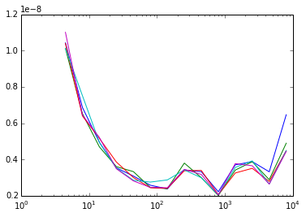

```
In [20] used -87.0352 MiB RAM in 3.84s, peaked 127.88 MiB above current, total RAM usage 567.95 MiB
```

```python
%%time
m=5
times=[0]*m

for j in range(m):
    print j,
    times[j]=[]
    for e in vals:
        chunk=int(L*10**(-e));
        t1=time()
        S=0
        for i in xrange(0,L,chunk):
            S+=np.dot(np.arange(i,i+chunk-1),np.arange(i,i+chunk-1))
        t2=time()
        ratio=(t2-t1)/L
        #print chunk,ratio
        sys.stdout.flush()
        times[j].append(ratio)

for i in range(m):
    plt.semilogx(chunks,times[i])
```

The exact shape of the graph depends on the load on the computer memory at that moment.

Observe that we have several minima at different sizes. These sizes typically are the page sizes for different cache levels.

```
 0 1 2 3 4CPU times: user 1.88 s, sys: 156 ms, total: 2.04 s
Wall time: 2.03 s
```

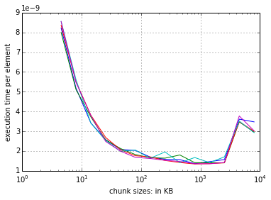

```
In [39] used 0.9922 MiB RAM in 2.58s, peaked 0.24 MiB above current, total RAM usage 399.75 MiB
```

```python
%%time
chunks=[]

def selfdot(v):
    return np.dot(v,v)

m=5
times=[0]*m

for j in range(m):
    print j,
    times[j]=[]
    for e in vals:
        chunk=int(L*10**(-e));
        t1=time()
        S=0
        for i in xrange(0,L,chunk):
            S+=selfdot(np.arange(i,i+chunk-1))
        t2=time()
        ratio=(t2-t1)/L
        #print chunk,ratio
        sys.stdout.flush()
        times[j].append(ratio)
        if j==0:
            chunks.append(chunk*8e-3)

for j in range(m):
    plt.semilogx(chunks,times[j])
plt.xlabel('chunk sizes: in KB')
plt.ylabel('execution time per element')
plt.grid()
```

### Using multiprocessing/Pool to use all cores.

The Pool class gives an easy way to run a program on multiple cores.

```python
from multiprocessing import Pool
```

```
In [23] used 0.0000 MiB RAM in 0.10s, peaked 0.00 MiB above current, total RAM usage 487.66 MiB
```

```python
def selfdot(v):
    global waste
    for i in range(waste): #waste time - represents extra calculation
        np.dot(v,v)
    return np.dot(v,v)

def multi_process(L=int(1e7),vals=np.arange(1,4.5,0.25)):

    times={}
    chunks=[]
    for ps in range(1,6):
        print ps,
        p=Pool(ps)   #create a pool of ps processes
        times[ps]=[]
        for e in vals:
            chunk=int(L*10**(-e))
            t1=time()
            ############# map = perform a command on each element of a list, using parallel processes.
            X=p.map(selfdot,[np.arange(i,i+chunk-1) for i in xrange(0,L,chunk)],)
            #############
            t2=time()
            ratio=(t2-t1)/(L*(1+waste))
            times[ps].append(ratio)
            if ps==1:
                chunks.append(chunk*8e-3)
        p.close() # close the pool

    for i in times.keys():
        plt.semilogx(chunks,times[i],label=str(i))

    plt.legend(bbox_to_anchor=(1.05, 1), loc=2, borderaxespad=0.)
    plt.grid()
```

```
In [46] used 0.0000 MiB RAM in 0.12s, peaked 0.00 MiB above current, total RAM usage 474.87 MiB
```

```
1 2 3 4 5
```

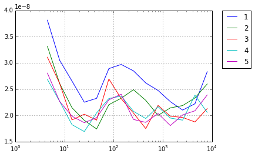

```
In [44] used -72.7344 MiB RAM in 16.66s, peaked 181.32 MiB above current, total RAM usage 470.18 MiB
```

```python
global waste
waste=0
multi_process()
```

The extra work involvd in mapping is much larger than the gain from multi-processing 1e-8 vs ie-9.

In order to see benefit, the amount of computation for each element has to be much larger. otherwise the added computer power gains you nothing.

```
1 2 3 4 5
```

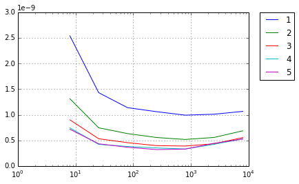

```
In [47] used -3.1797 MiB RAM in 25.17s, peaked 203.96 MiB above current, total RAM usage 471.69 MiB
```

```python
global waste  # the dot product is computer waste+1 times.
waste=100
multi_process(vals=np.arange(1,4.5,0.5))
```

When performing the dot product 101 times we can see a significant imporvement from 1 to 2 processes, less from 2-3 and 3-4. No improvement beyond 4. Which makes sense, because the laptop has only 4 cores.

## Performance when data is out of memory

```python
f=open ('a.bin','rb')
```

```
In [81] used 0.0000 MiB RAM in 0.11s, peaked 0.00 MiB above current, total RAM usage 469.53 MiB
```

```python
vals=np.arange(2,9)
chunks=[int(10**e) for e in vals]
for chunk in chunks:
    s=0
    A=np.array([0,0])
    t0=time()
    with open('a.bin','rb') as f:
        while np.size(A)>0:
            A=np.fromfile(f,count=chunk)
            v=np.reshape(A,(-1,2))
            s+= np.dot(v[:,0],v[:,1])
    t1=time()
    print (t1-t0)/(1e8),'time per element', (chunk*8)/(1e6), 'MB'
```

```
2.10549969673e-07 time per element 0.0008 MB
2.82002687454e-08 time per element 0.008 MB
6.08550071716e-09 time per element 0.08 MB
3.52241039276e-09 time per element 0.8 MB
7.78764009476e-09 time per element 8.0 MB
7.29969978333e-09 time per element 80.0 MB
1.0617980957e-08 time per element 800.0 MB
In [91] used 0.0000 MiB RAM in 27.52s, peaked 1366.69 MiB above current, total RAM usage 622.69 MiB
```

The best block size is about 1MB. At that block size we achieve a throughput close to that of numpy using memory directly which is (see beginning of this notebook) 1-2 nano-second (1e-9)

I say that this size block is **impedance matched** to the hardware. It is the block-size where cache blocks are filled exactly and the computation proceeds smoothly and fast.